# Project 3

Chuwen Liu

## Introduction to the dataset and things we want to explore

Urban Ministries of Durham provides various datasets for us to explore the different aspects of the client who once entered the shelter provided by UMD seeking for help, and based on the large amount data, we will be able to make some analysis for UMD to master the description and characteristics precisely, and make a better preparation for the future client.

We will show the wrangling process in python and make some plots in R. The variables we will use mainly contain: * Demographic statistics, including the race, age, ethinicity, gender… * Time statistics, including the date who enter the shelter, the date who exit the shelter, the start and end date for income, health insurance… * Categorical statistics for living condition, such as the health insurance coverage, living status, monthly income source, disability type.

We want to use some kind of variables to construct the correlation with staying time at the shelter. Also, we will see if there’s some variables highly correlated, and consider the comparison between entry and exit to see if clients got enough help in shelters. Based on these two analysis, we will also conduct some other interesting analysis work.

## Exploration: Different variables vs the length of staying time

In the first part we will draw lot of plots to explore the variables listed in our dataset, and also try to see if there’s correlation with duration.

### The distribution plot for the staying duration and visiting times

First I would like to explain the variables here: “Disability count” means that the total amount of disability the client has; “healins” has the similar meaning as for health insurance. And the “income_month” add all the income source of the client. “Receiving Benefit” means the amount of noncash support they received at first.

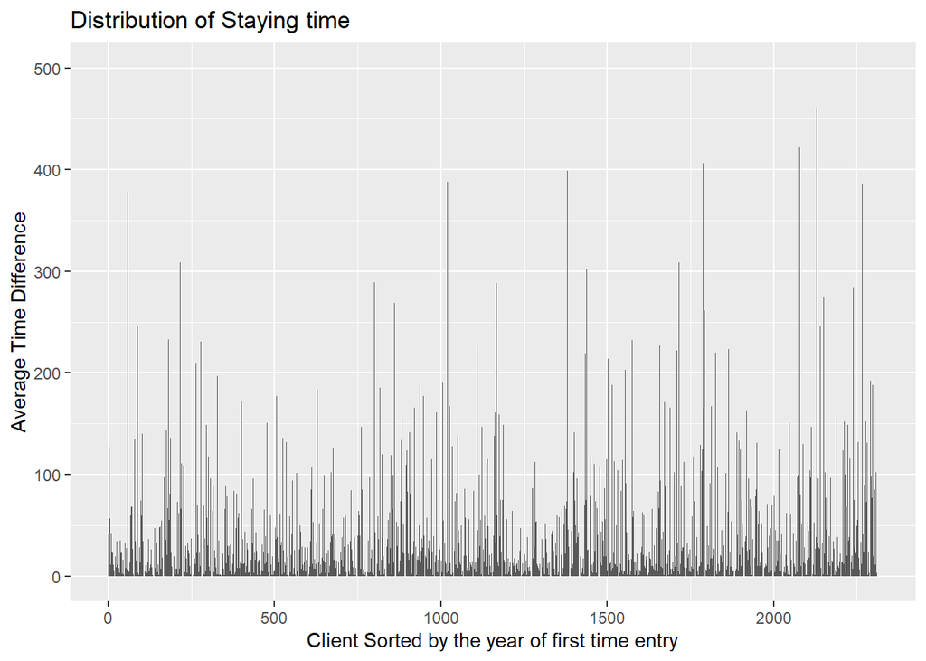

```r
p1 = client.entry %>%drop_na(`Time Difference`)%>%group_by(`Client ID`)%>%
  summarise(td = mean(`Time Difference`),age = min(Entry_age), visit = mean(Visit_time))%>%arrange(age)%>%mutate(index = 1:2311)
ggplot(p1,aes(x=index,y=td))+geom_bar(size = 1.5,alpha = 1,stat="identity")+
  labs(x = "Client Sorted by the year of first time entry",y= "Average Time Difference",title ="Distribution of Staying time")+ylim(c(0,500))
```

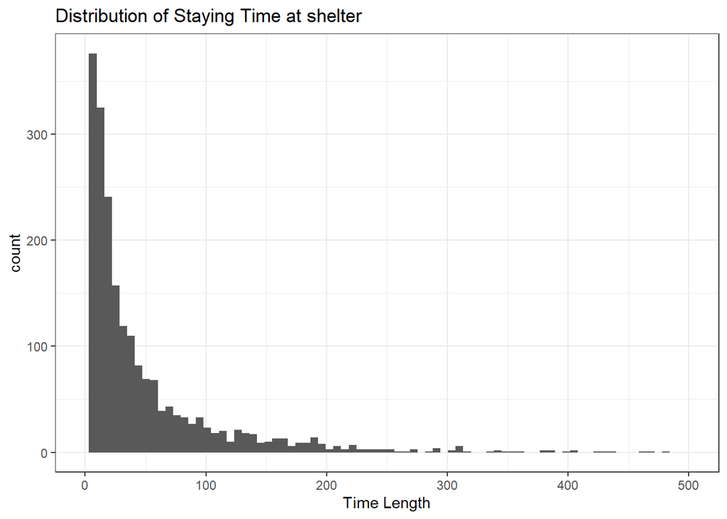

```r
ggplot(p1,aes(x= td))+geom_histogram(bins = 80)+xlim(c(0,500))+labs(x="Time Length",title="Distribution of Staying Time at shelter")+theme_bw()
```

```r
client.entry%>%select(`Time Difference`)%>%arrange(desc(`Time Difference`))
```

```
## # A tibble: 5,299 x 1
##    `Time Difference`
##                <dbl>
##  1               894
##  2               574
##  3               550
##  4               515
##  5               515
##  6               510
##  7               484
##  8               484
##  9               467
## 10               461
## # ... with 5,289 more rows
```

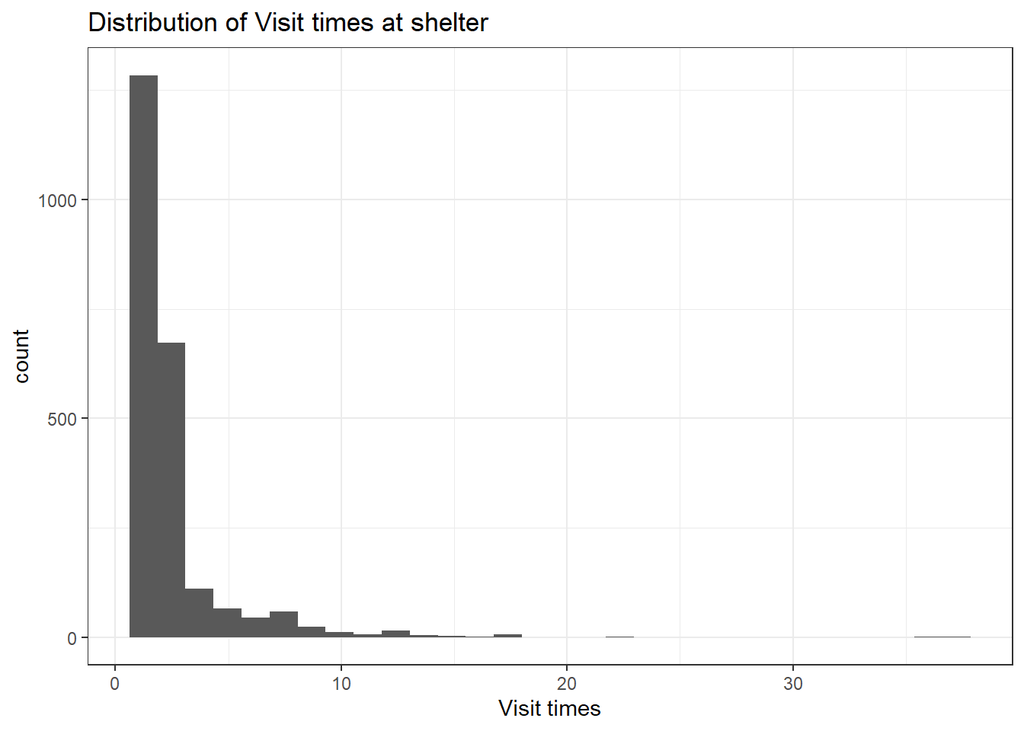

```r
ggplot(p1,aes(x= visit))+geom_histogram(bins = 30)+labs(x="Visit times",title="Distribution of Visit times at shelter")+theme_bw()
```

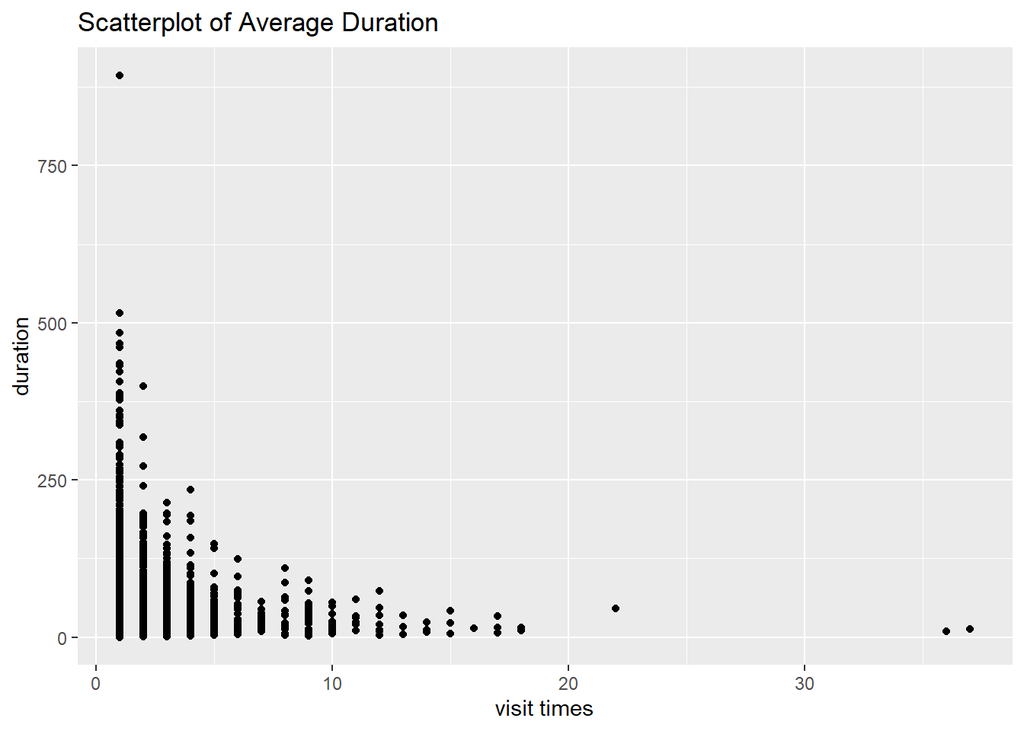

```r
# Scatterplot of Duration and Visit times
client.entry%>%group_by(`Client ID`)%>%summarise(visit = mean(Visit_time),duration = mean(`Time Difference`))%>%
  ggplot(aes(x = visit, y = duration))+geom_point(size = 1.5)+labs(x="visit times",y="duration",title = "Scatterplot of Average Duration")
```

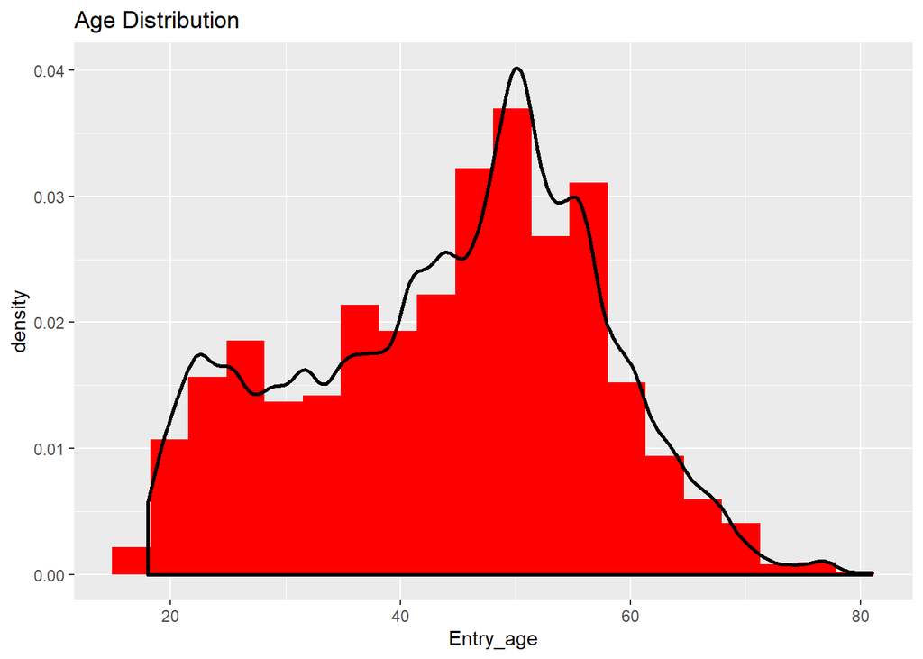

```r
#Histogram of entry age
client.entry%>%ggplot(aes(x= Entry_age,y=..density..))+geom_histogram(bins = 20, fill = "red")+geom_density(adjust = 0.5,size=1)+ggtitle("Age Distribution")
```

Since our initial dataset contains some clients’ multiple records on visiting the shelter, we will use a new dataset which will only contain one data row for every client.

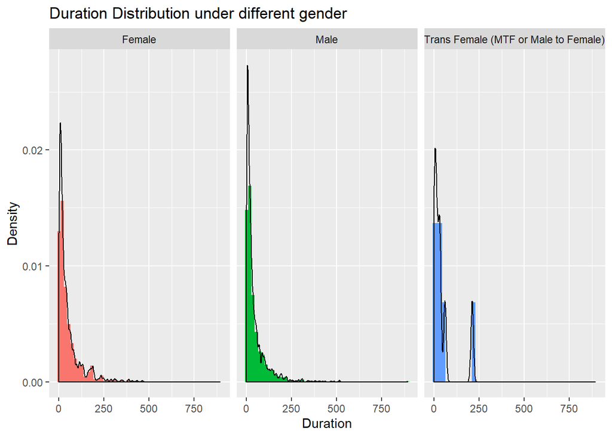

```r
tp = client.entry%>%drop_na("Time Difference")%>%group_by(`Client ID`)%>% summarise(duration.ave = mean(`Time Difference`))

client.entry.new = client.demo%>%left_join(tp,by = "Client ID")

client.entry.new%>%drop_na(`Client Gender`)%>%
    ggplot(aes(x=duration.ave,y=..density..))+geom_histogram(bins=50,aes(fill=`Client Gender`))+facet_wrap(~`Client Gender`)+geom_density(adjust = 0.5)+guides(fill=F)+labs(x="Duration",y="Density",title = "Duration Distribution under different gender")
```

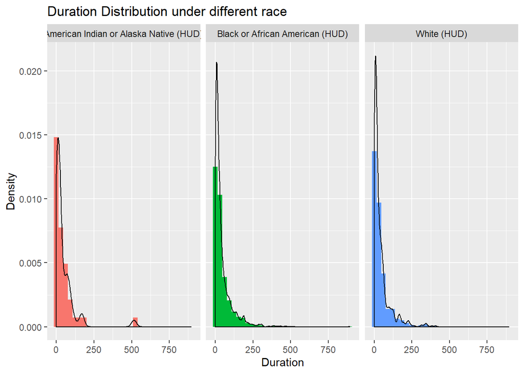

```r
 client.entry.new%>%filter(race %in% c("Black or African American (HUD)","White (HUD)","American Indian or Alaska Native (HUD)"))%>%
   ggplot(aes(x=duration.ave,y=..density..))+geom_histogram(bins=30,aes(fill=race),position="identity")+geom_density()+facet_grid(.~race)+guides(fill=F)+labs(x="Duration",y="Density",title = "Duration Distribution under different race")
```

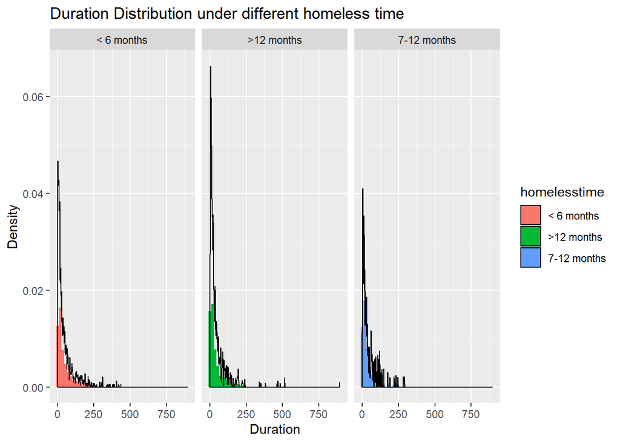

```r
# For the race variable, we have more black people than white people, so we let the y axis represent density.

client.entry.new%>%drop_na(homelesstime)%>%
     ggplot(aes(x=duration.ave,y=..density..))+geom_histogram(bins=50,aes(fill=homelesstime))+geom_density(adjust=0.05)+facet_grid(.~homelesstime)+
  labs(x="Duration",y="Density",title = "Duration Distribution under different homeless time")
```

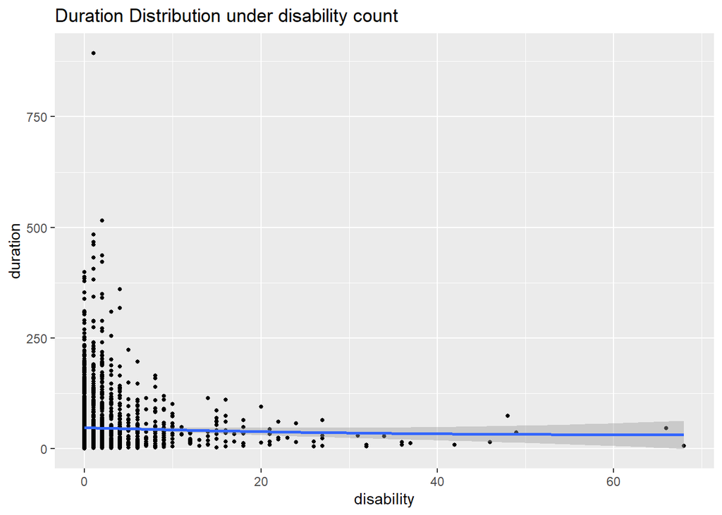

```r
client.entry.new%>%drop_na(`Disability count`)%>%
    ggplot(aes(x = `Disability count`,y=duration.ave))+geom_point(size = 1)+geom_smooth()+labs(x="disability",y="duration",title = "Duration Distribution under disability count")
```

For different variables, the duration distribution does not seem to differ a lot, but still I found that for gender, the amount of men is more than women when the duration is short; the amount of people who are homeless for more than one year will be more possible to stay at shelter shortly.

### Distribution of the different potential independent variables: Monthly income

We will explore the other important variables’ distribution and correlation among them. We take monthly income as our goal.

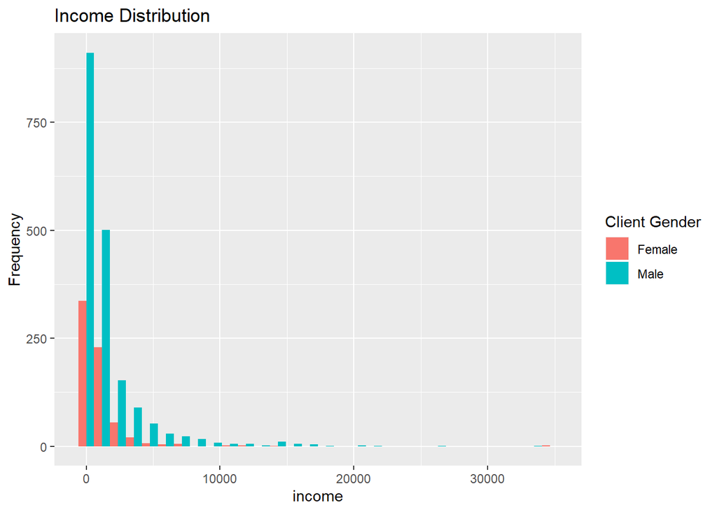

```r
# Exploration of the monthly income
#Group by two main gender

client.entry.new%>%drop_na(income_month)%>%filter(`Client Gender` %in% c("Female","Male"))%>%ggplot(aes(x=income_month,fill = `Client Gender`))+geom_histogram(bins = 30,position = "dodge")+
  labs(x = "income",y = "Frequency",title = "Income Distribution")
```

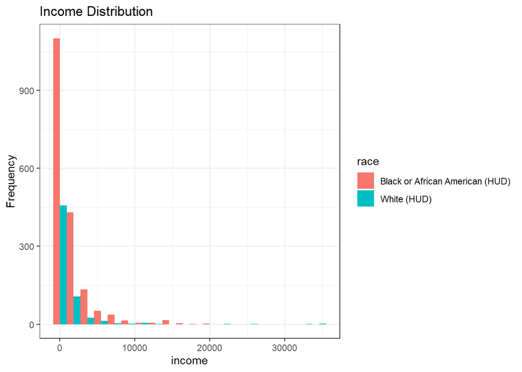

```r
# Group by two main race
client.entry.new%>%filter(race %in% c("Black or African American (HUD)","White (HUD)"),`Client Gender` %in% c("Female","Male"))%>%drop_na(income_month)%>% ggplot(aes(x=income_month,fill = race))+
  geom_histogram(bins = 20,position = "dodge")+theme_bw()+labs(x = "income",y = "Frequency",title = "Income Distribution")
```

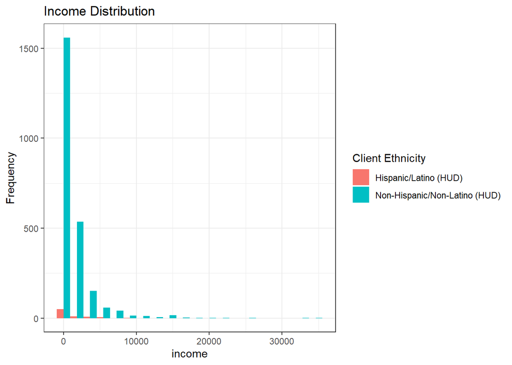

```r
#Group by two main ethnicity
client.entry.new%>%filter(`Client Ethnicity` %in% c("Non-Hispanic/Non-Latino (HUD)","Hispanic/Latino (HUD)"))%>%drop_na(income_month)%>%
  ggplot(aes(x=income_month,fill = `Client Ethnicity`))+geom_histogram(bins = 20,position = "dodge")+theme_bw()+labs(x = "income",y = "Frequency",title = "Income Distribution")
```

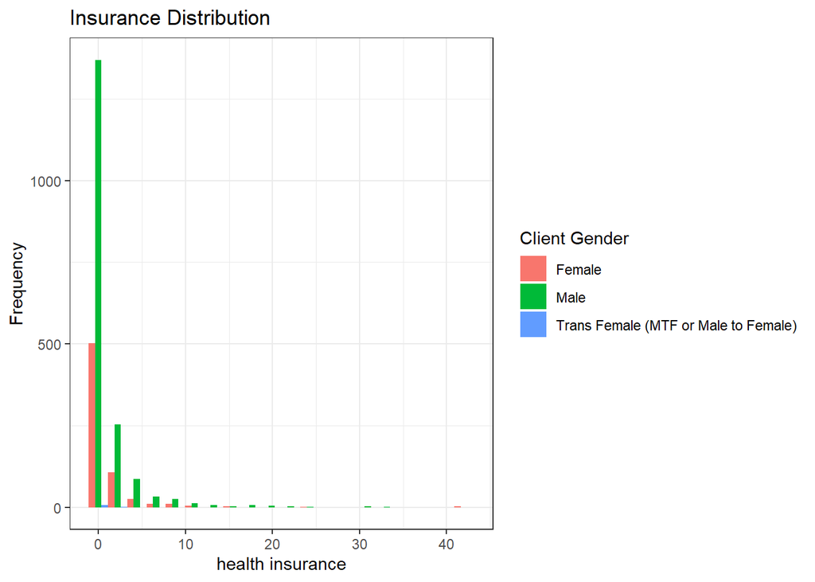

```r
#Distribution of Client's health insurance amount
client.entry.new%>%drop_na(healins)%>%filter(healins < 50)%>%ggplot(aes(x =healins,fill = `Client Gender`))+
  geom_histogram(bins = 20,position = "dodge")+theme_bw()+labs(x = "health insurance",y = "Frequency",title = "Insurance Distribution")
```

### Correlation among variables

We will mainly use scatterplot to compare some variables’ correlation. And we will remove some outliers.

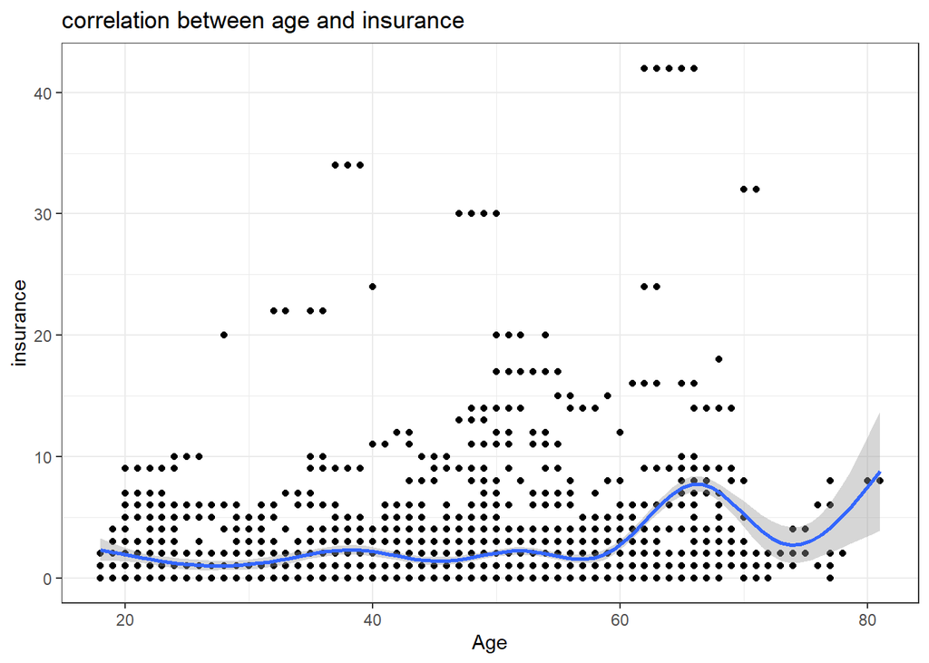

```r
# Age vs health insurance
client.entry%>%drop_na(healins)%>%filter(healins < 50)%>%ggplot(aes(x =Entry_age,y = healins))+geom_point()+geom_smooth()+theme_bw()+labs(x="Age",y = "insurance",title = "correlation between age and insurance")
```

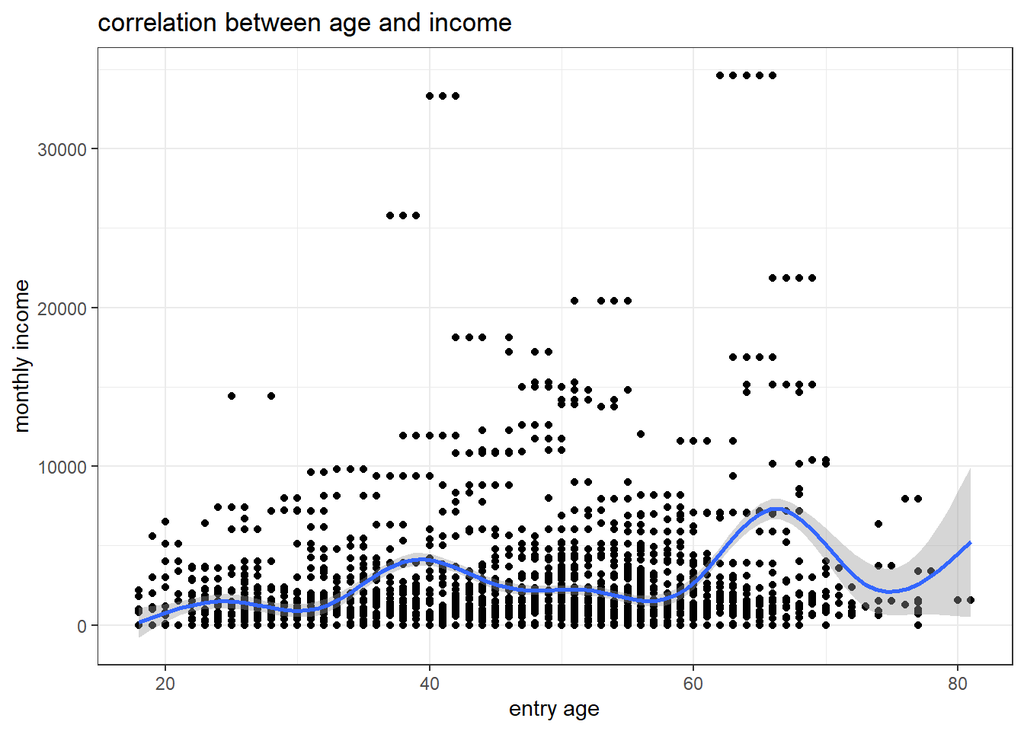

```r
# Age vs monthly income
client.entry%>%ggplot(aes(x =Entry_age,y = income_month))+geom_point()+geom_smooth()+theme_bw()+labs(y="monthly income",x ="entry age",title = "correlation between age and income")
```

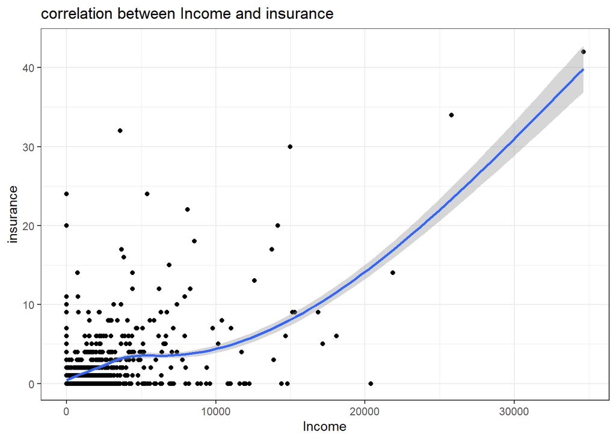

```r
# health insurance vs monthly income
client.entry.new%>%drop_na(healins,income_month)%>%filter(healins < 50)%>%ggplot(aes(x =income_month,y = healins))+geom_point()+geom_smooth()+theme_bw()+labs(x="Income",y = "insurance",title = "correlation between Income and insurance")
```

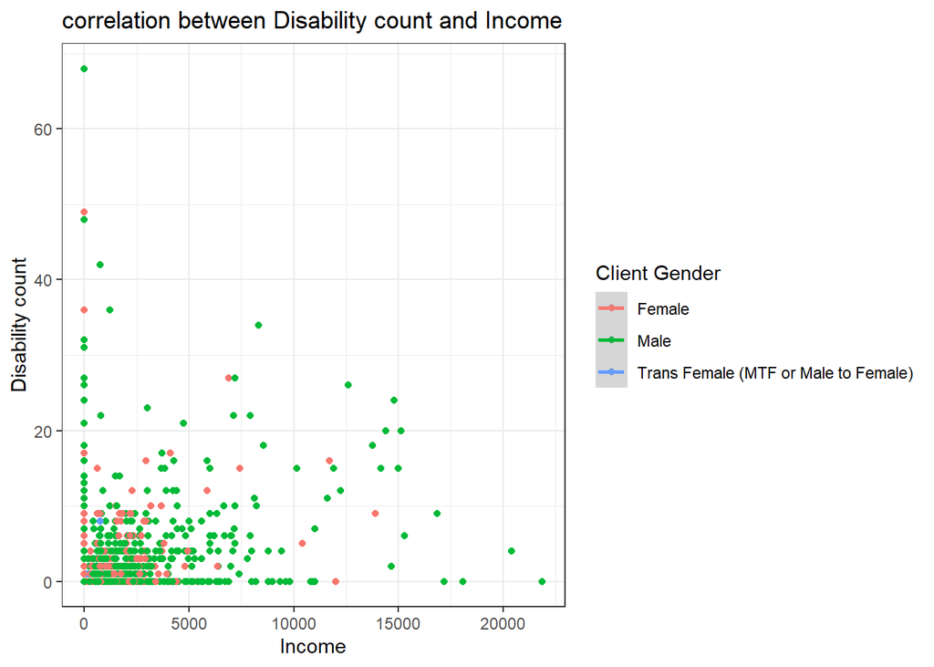

```r
#Disability amount vs monthly income
client.entry.new%>%filter(income_month < 25000)%>%drop_na(`Disability count`,income_month)%>%ggplot(aes(x =income_month,y = `Disability count`,col = `Client Gender`))+geom_point()+geom_smooth()+theme_bw()+labs(x="Income",y = "Disability count",title = "correlation between Disability count and Income")
```

[figure not shown]

```r
#NonCash benefit vs monthly income
client.entry%>%filter(healins < 50)%>%drop_na(`Receiving Benefit (Entry)`,healins)%>%ggplot(aes(y =income_month,x = `Receiving Benefit (Entry)`))+geom_point()+geom_smooth()+theme_bw()+labs(x="Income",y = "Disability count",title = "correlation between noncash benefit and Income")
```

```r
# Conduct correlation test and draw the corrplot
cor.test(client.entry.new$duration.ave,client.entry.new$income_month)
```

```
##
##  Pearson's product-moment correlation
##
## data:  client.entry.new$duration.ave and client.entry.new$income_month
## t = -0.82681, df = 2440, p-value = 0.4084
## alternative hypothesis: true correlation is not equal to 0
## 95 percent confidence interval:
##  -0.05636418  0.02294488
## sample estimates:
##         cor
## -0.01673597
```

```r
cor.test(client.entry.new$duration.ave,client.entry.new$healins)
```

```
##
##  Pearson's product-moment correlation
##
## data:  client.entry.new$duration.ave and client.entry.new$healins
## t = -1.4304, df = 2425, p-value = 0.1527
## alternative hypothesis: true correlation is not equal to 0
## 95 percent confidence interval:
##  -0.06874346  0.01076562
## sample estimates:
##         cor
## -0.02903484
```

```r
cor.test(client.entry.new$duration.ave,client.entry.new$`Disability count`)
```

```
##
##  Pearson's product-moment correlation
##
## data:  client.entry.new$duration.ave and client.entry.new$`Disability count`
## t = -2.3579, df = 2438, p-value = 0.01846
## alternative hypothesis: true correlation is not equal to 0
## 95 percent confidence interval:
##  -0.08721690 -0.00803344
## sample estimates:
##         cor
## -0.04770011
```

```r
cor.test(client.entry$`Time Difference`,client.entry$Entry_age)
```

```
##
##  Pearson's product-moment correlation
##
## data:  client.entry$`Time Difference` and client.entry$Entry_age
## t = 7.713, df = 5187, p-value = 1.464e-14
## alternative hypothesis: true correlation is not equal to 0
## 95 percent confidence interval:
##  0.07950589 0.13330878
## sample estimates:
##       cor
## 0.1064853
```

```r
cordat = as.data.frame(client.entry%>%select(`Time Difference`,income_month,healins,Entry_age,`Disability count`,`Receiving Benefit (Entry)`)%>%drop_na(`Time Difference`,income_month,healins,Entry_age,`Disability count`,`Receiving Benefit (Entry)`))
A = cor(cordat)
A
```

```
##                           Time Difference income_month     healins
## Time Difference                1.00000000  -0.03225535 -0.04951996
## income_month                  -0.03225535   1.00000000  0.74223560
## healins                       -0.04951996   0.74223560  1.00000000
## Entry_age                      0.10316693   0.13382599  0.05066760
## Disability count              -0.08473428   0.46001351  0.44999391
## Receiving Benefit (Entry)     -0.02480487   0.23800552  0.14891873
##                            Entry_age Disability count
## Time Difference           0.10316693      -0.08473428
## income_month              0.13382599       0.46001351
## healins                   0.05066760       0.44999391
## Entry_age                 1.00000000       0.11595581
## Disability count          0.11595581       1.00000000
## Receiving Benefit (Entry) 0.04091241       0.34317431
##                           Receiving Benefit (Entry)
## Time Difference                         -0.02480487
## income_month                             0.23800552
## healins                                  0.14891873
## Entry_age                                0.04091241
## Disability count                         0.34317431
## Receiving Benefit (Entry)                1.00000000
```

## Make some test between entry data and exit data

Since we are given two datasets, we could do some parametric or nonparametric testing to check if there’s a change after leaving the shelter.

For example, we are interested in the change of mean in income and disability count. Will it differ a lot?

```r
t.test(client.entry$income_month-client.exit$income_month_exit)
```

```
##
##  One Sample t-test
##
## data:  client.entry$income_month - client.exit$income_month_exit
## t = -20.038, df = 5049, p-value < 2.2e-16
## alternative hypothesis: true mean is not equal to 0
## 95 percent confidence interval:
##  -154.6366 -127.0753
## sample estimates:
## mean of x
## -140.8559
```

```r
t.test(client.entry$`Disability count`,client.exit$`Disability count`,paired= TRUE,var.equal = FALSE)
```

```
##
##  Paired t-test
##
## data:  client.entry$`Disability count` and client.exit$`Disability count`
## t = -10.389, df = 5030, p-value < 2.2e-16
## alternative hypothesis: true difference in means is not equal to 0
## 95 percent confidence interval:
##  -0.07230042 -0.04934537
## sample estimates:
## mean of the differences
##              -0.0608229
```

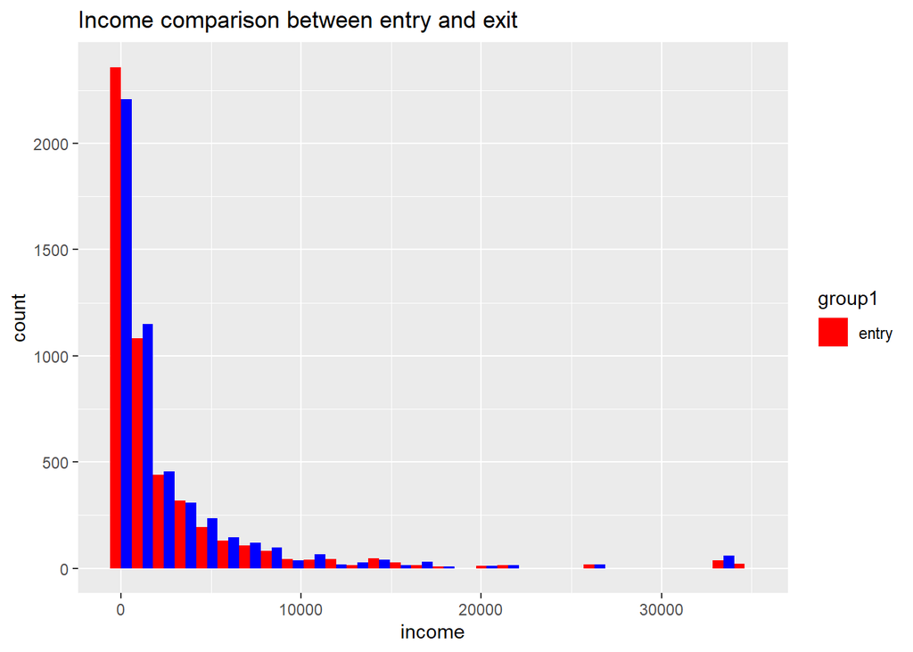

```r
# Also draw the distribution plot to compare
data.frame(client.entry$income_month,client.exit$income_month_exit)%>%gather(client.entry.income_month,client.exit.income_month_exit,key = "group1", value = "income")%>%ggplot(aes(x=income,fill = group1,group = group1))+geom_histogram(bins = 30,position="dodge")+
  scale_fill_manual(values=c("red","blue"),labels = c("entry","exit"),breaks = c("client.entry.income_month","client.exit.income_month"))+ggtitle("Income comparison between entry and exit")
```

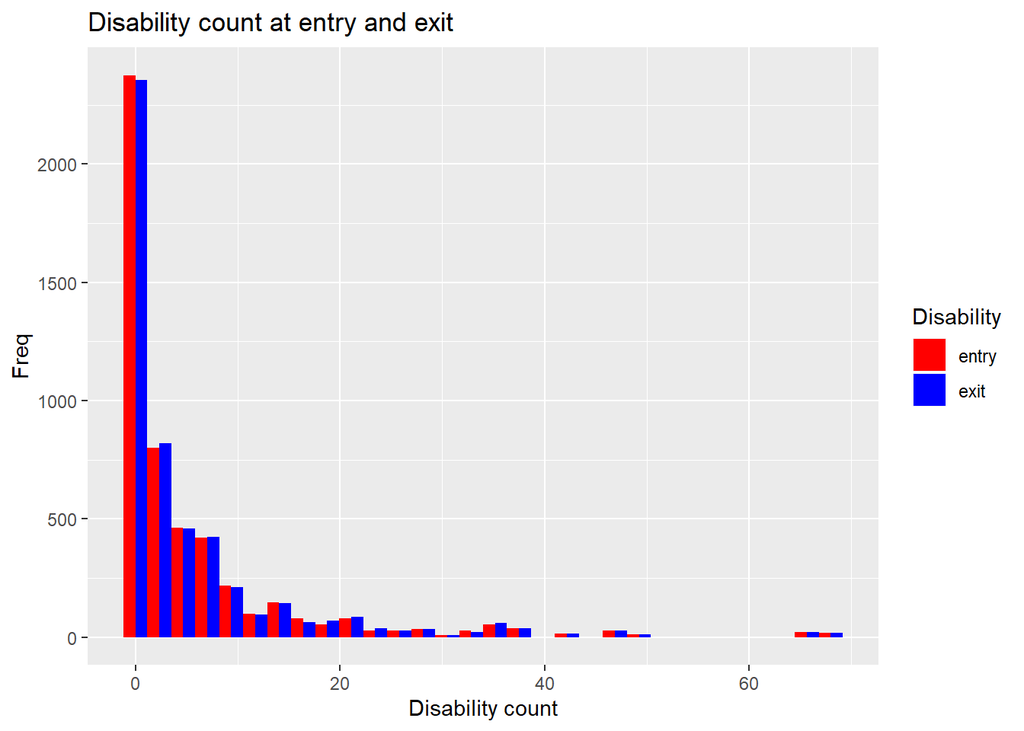

```r
data.frame(client.entry$`Disability count`,client.exit$`Disability count`)%>%gather(client.entry..Disability.count.,client.exit..Disability.count.,key = "Disability", value = "count")%>%
  ggplot(aes(x=count,fill = Disability,group = Disability))+geom_histogram(bins = 30,position="dodge")+
  scale_fill_manual(values=c("red","blue"),labels = c("entry","exit"),breaks = c("client.entry..Disability.count.","client.exit..Disability.count."))+labs(x="Disability count",y="Freq",title = "Disability count at entry and exit")
```

## Construct the linear model

Since we want to make a linear model based on our variables, we will firstly use some characteristics; we will first include all the variables and then decide which one should be included in the final one.

```r
#Construct the model
dt = client.entry%>%filter(race %in% c("Black or African American (HUD)","White (HUD)","American Indian or Alaska Native (HUD)"),`Client Gender`%in% c("Male","Female"))

mod1 =lm(`Time Difference`~ Entry_age+`Client Gender`+race+`Client Veteran Status`+`Client Ethnicity`+income_month+healins+`Disability count`+`Receiving Benefit (Entry)`+homelesstime,data =dt)

summary(mod1)
```

```
##
## Call:
## lm(formula = `Time Difference` ~ Entry_age + `Client Gender` +
##     race + `Client Veteran Status` + `Client Ethnicity` + income_month +
##     healins + `Disability count` + `Receiving Benefit (Entry)` +
##     homelesstime, data = dt)
##
## Residuals:
##    Min     1Q Median     3Q    Max
## -65.91 -33.76 -20.79   6.92 529.90
##
## Coefficients:
##                                                   Estimate Std. Error
## (Intercept)                                     18.0497254 10.1765406
## Entry_age                                        0.5896283  0.0804013
## `Client Gender`Male                             -5.7619078  2.3535638
## raceBlack or African American (HUD)             -2.7672987  7.8457708
## raceWhite (HUD)                                 -4.9020090  8.0219895
## `Client Veteran Status`Yes (HUD)                -9.4855934  3.3628351
## `Client Ethnicity`Non-Hispanic/Non-Latino (HUD) 12.0942522  5.6656433
## income_month                                     0.0002789  0.0003197
## healins                                         -0.2051081  0.2882905
## `Disability count`                              -0.5101565  0.1158894
## `Receiving Benefit (Entry)`                      0.1521957  0.3649462
## homelesstime>12 months                          -8.3048505  2.1536475
## homelesstime7-12 months                         -7.3223762  4.0636846
##                                                 t value Pr(>|t|)
## (Intercept)                                       1.774 0.076196 .
## Entry_age                                         7.334  2.7e-13 ***
## `Client Gender`Male                              -2.448 0.014402 *
## raceBlack or African American (HUD)              -0.353 0.724323
## raceWhite (HUD)                                  -0.611 0.541187
## `Client Veteran Status`Yes (HUD)                 -2.821 0.004815 **
## `Client Ethnicity`Non-Hispanic/Non-Latino (HUD)   2.135 0.032849 *
## income_month                                      0.872 0.383093
## healins                                          -0.711 0.476839
## `Disability count`                               -4.402  1.1e-05 ***
## `Receiving Benefit (Entry)`                       0.417 0.676675
## homelesstime>12 months                           -3.856 0.000117 ***
## homelesstime7-12 months                          -1.802 0.071636 .
## ---
## Signif. codes:  0 '***' 0.001 '**' 0.01 '*' 0.05 '.' 0.1 ' ' 1
##
## Residual standard error: 61.96 on 3971 degrees of freedom
##   (1266 observations deleted due to missingness)
## Multiple R-squared:  0.02675,    Adjusted R-squared:  0.02381
## F-statistic: 9.097 on 12 and 3971 DF,  p-value: < 2.2e-16
```

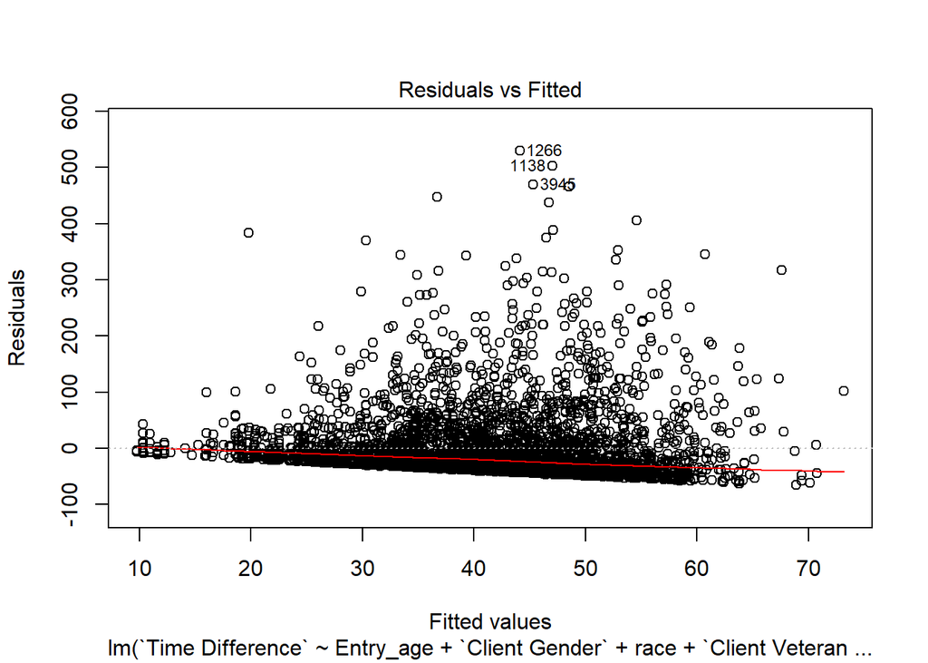

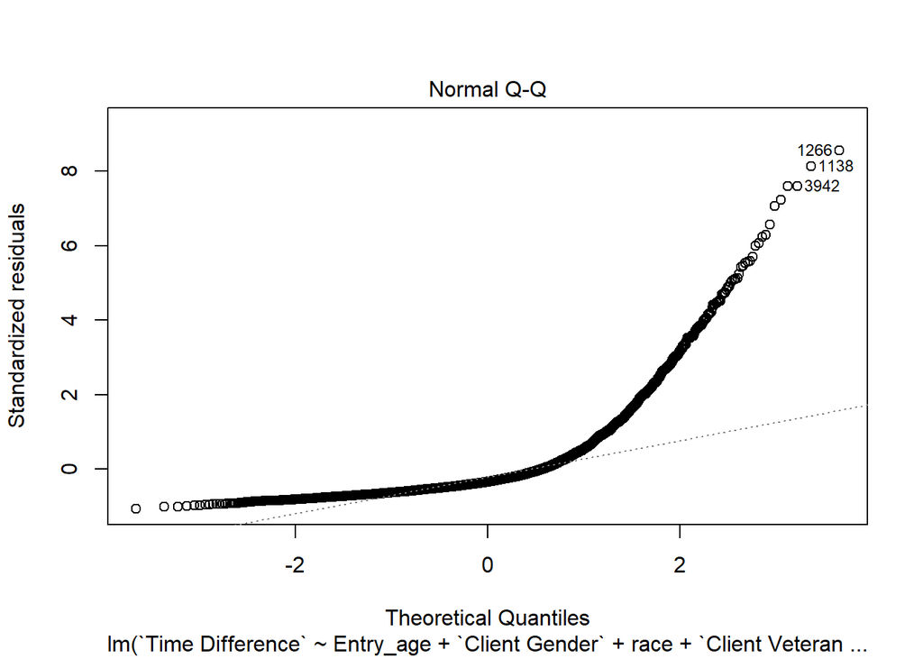

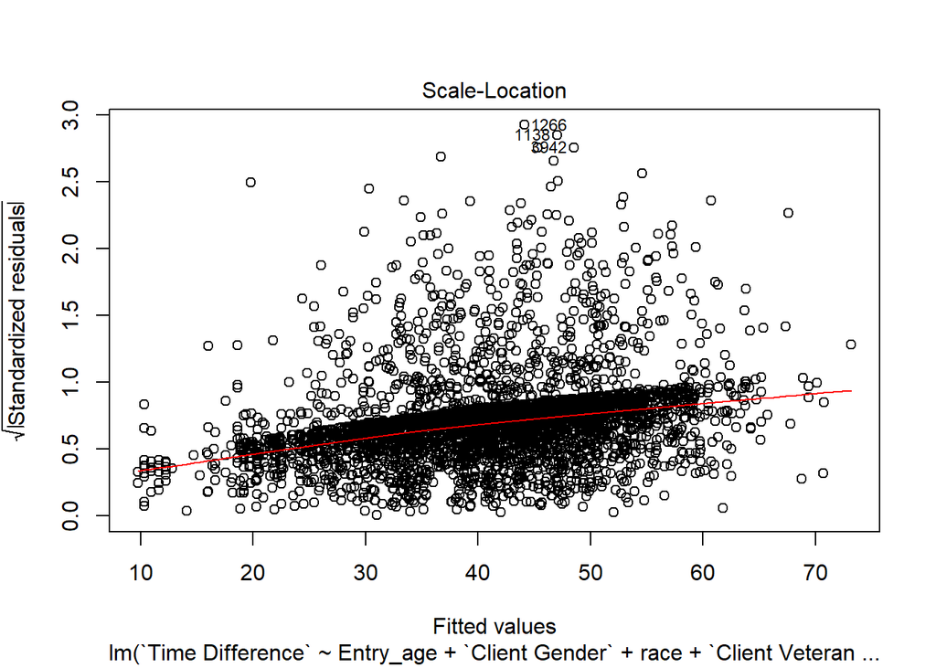

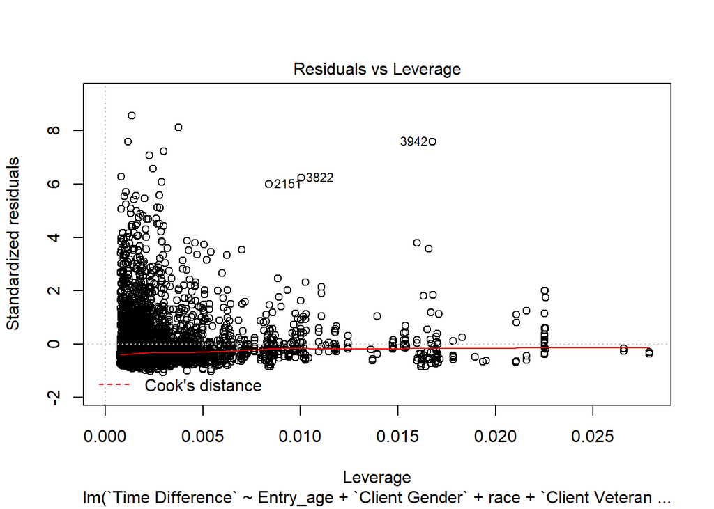

```r
plot(mod1)
```

```r
mod2 =lm(`Time Difference`~ Entry_age+`Client Veteran Status`+`Client Ethnicity`+`Disability count`+homelesstime,data =dt)
summary(mod2)
```

```
##
## Call:
## lm(formula = `Time Difference` ~ Entry_age + `Client Veteran Status` +
##     `Client Ethnicity` + `Disability count` + homelesstime, data = dt)
##
## Residuals:
##    Min     1Q Median     3Q    Max
## -62.47 -34.13 -21.13   6.84 849.73
##
## Coefficients:
##                                                 Estimate Std. Error
## (Intercept)                                       7.4397     6.4531
## Entry_age                                         0.6188     0.0807
## `Client Veteran Status`Yes (HUD)                -11.7297     3.3484
## `Client Ethnicity`Non-Hispanic/Non-Latino (HUD)  14.6093     5.5445
## `Disability count`                               -0.5101     0.1034
## homelesstime>12 months                           -8.2049     2.1681
## homelesstime7-12 months                          -6.1834     4.0993
##                                                 t value Pr(>|t|)
## (Intercept)                                       1.153 0.249026
## Entry_age                                         7.668 2.18e-14 ***
## `Client Veteran Status`Yes (HUD)                 -3.503 0.000465 ***
## `Client Ethnicity`Non-Hispanic/Non-Latino (HUD)   2.635 0.008448 **
## `Disability count`                               -4.932 8.45e-07 ***
## homelesstime>12 months                           -3.784 0.000156 ***
## homelesstime7-12 months                          -1.508 0.131533
## ---
## Signif. codes:  0 '***' 0.001 '**' 0.01 '*' 0.05 '.' 0.1 ' ' 1
##
## Residual standard error: 63.47 on 4049 degrees of freedom
##   (1194 observations deleted due to missingness)
## Multiple R-squared:  0.02545,    Adjusted R-squared:  0.024
## F-statistic: 17.62 on 6 and 4049 DF,  p-value: < 2.2e-16
```

From the plot we could see there’s a linear correlation between residuals and fitted values, so the residuals still contain the information for fitted values; We found that “Entry Age”,gender,veteran status, ethnicity, disability count and homeless time have the significant p-value, and the signal of estimate coefficients uncover the effect on the change of Duration. It passes F test but the $R^{2}$ statistics is very small. We might consider transform our response variable, such as using $\log(y)$;

```r
dt = dt%>%filter(`Time Difference`>0)
mod3 =lm(log(`Time Difference`)~ Entry_age+`Client Gender`+race+`Client Veteran Status`+`Client Ethnicity`+income_month+healins+`Disability count`+`Receiving Benefit (Entry)`+homelesstime,data =dt)

summary(mod3)
```

```
##
## Call:
## lm(formula = log(`Time Difference`) ~ Entry_age + `Client Gender` +
##     race + `Client Veteran Status` + `Client Ethnicity` + income_month +
##     healins + `Disability count` + `Receiving Benefit (Entry)` +
##     homelesstime, data = dt)
##
## Residuals:
##     Min      1Q  Median      3Q     Max
## -3.5099 -1.0129  0.0154  1.0426  4.0275
##
## Coefficients:
##                                                   Estimate Std. Error
## (Intercept)                                      2.350e+00  2.333e-01
## Entry_age                                        1.244e-02  1.845e-03
## `Client Gender`Male                             -2.031e-01  5.404e-02
## raceBlack or African American (HUD)             -3.203e-02  1.798e-01
## raceWhite (HUD)                                 -7.202e-02  1.839e-01
## `Client Veteran Status`Yes (HUD)                -1.502e-01  7.733e-02
## `Client Ethnicity`Non-Hispanic/Non-Latino (HUD)  2.578e-01  1.299e-01
## income_month                                     1.983e-05  7.351e-06
## healins                                          2.373e-03  6.623e-03
## `Disability count`                              -1.844e-02  2.664e-03
## `Receiving Benefit (Entry)`                      1.045e-02  8.376e-03
## homelesstime>12 months                          -2.579e-01  4.945e-02
## homelesstime7-12 months                         -7.795e-02  9.344e-02
##                                                 t value Pr(>|t|)
## (Intercept)                                      10.071  < 2e-16 ***
## Entry_age                                         6.741 1.80e-11 ***
## `Client Gender`Male                              -3.758 0.000173 ***
## raceBlack or African American (HUD)              -0.178 0.858646
## raceWhite (HUD)                                  -0.392 0.695325
## `Client Veteran Status`Yes (HUD)                 -1.943 0.052109 .
## `Client Ethnicity`Non-Hispanic/Non-Latino (HUD)   1.986 0.047155 *
## income_month                                      2.698 0.007006 **
## healins                                           0.358 0.720156
## `Disability count`                               -6.923 5.14e-12 ***
## `Receiving Benefit (Entry)`                       1.248 0.212174
## homelesstime>12 months                           -5.215 1.94e-07 ***
## homelesstime7-12 months                          -0.834 0.404202
## ---
## Signif. codes:  0 '***' 0.001 '**' 0.01 '*' 0.05 '.' 0.1 ' ' 1
##
## Residual standard error: 1.42 on 3955 degrees of freedom
##   (1161 observations deleted due to missingness)
## Multiple R-squared:  0.03837,    Adjusted R-squared:  0.03545
## F-statistic: 13.15 on 12 and 3955 DF,  p-value: < 2.2e-16
```

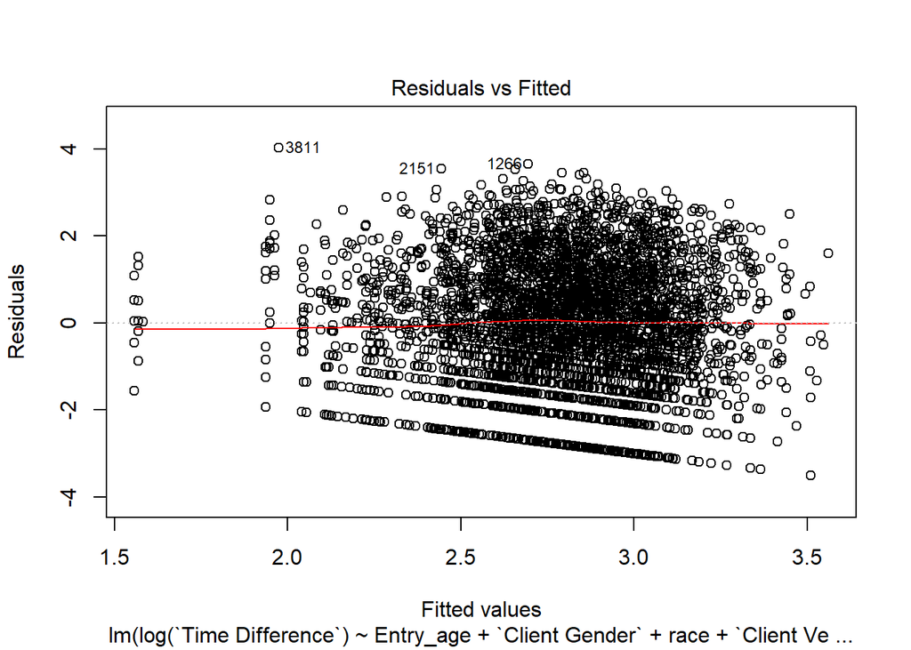

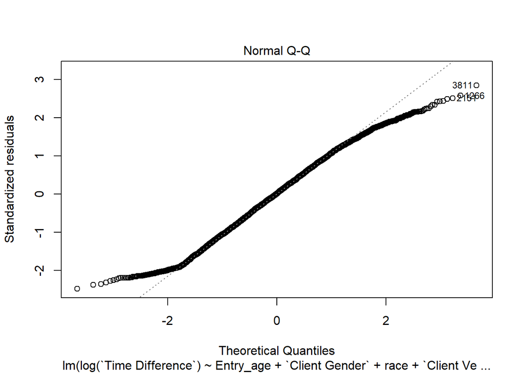

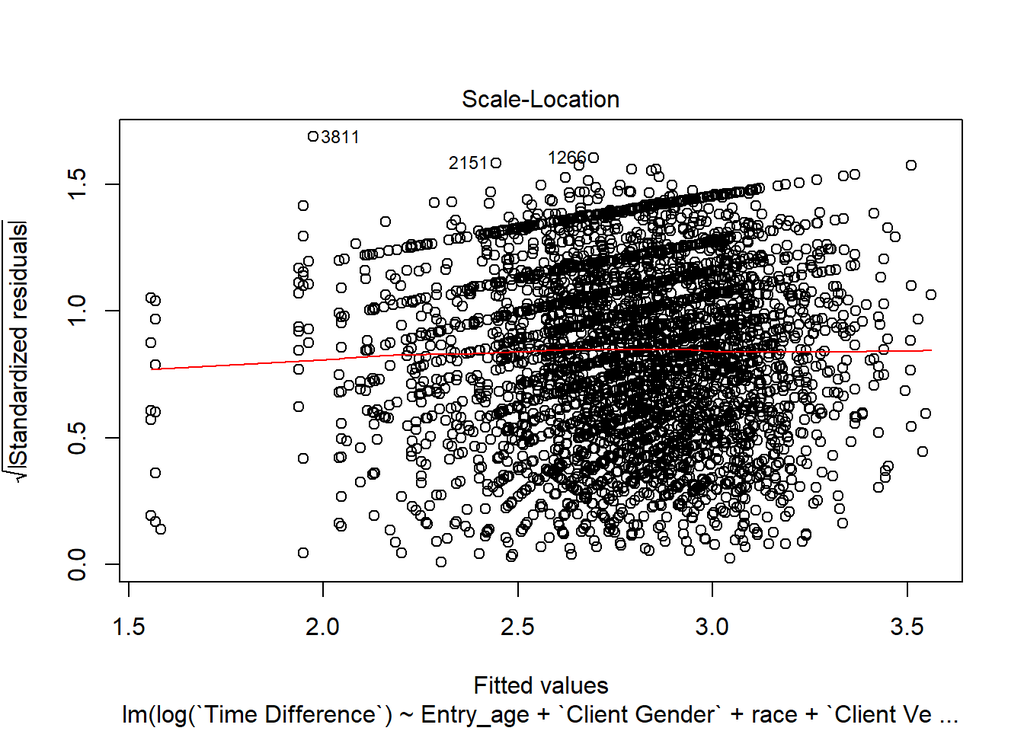

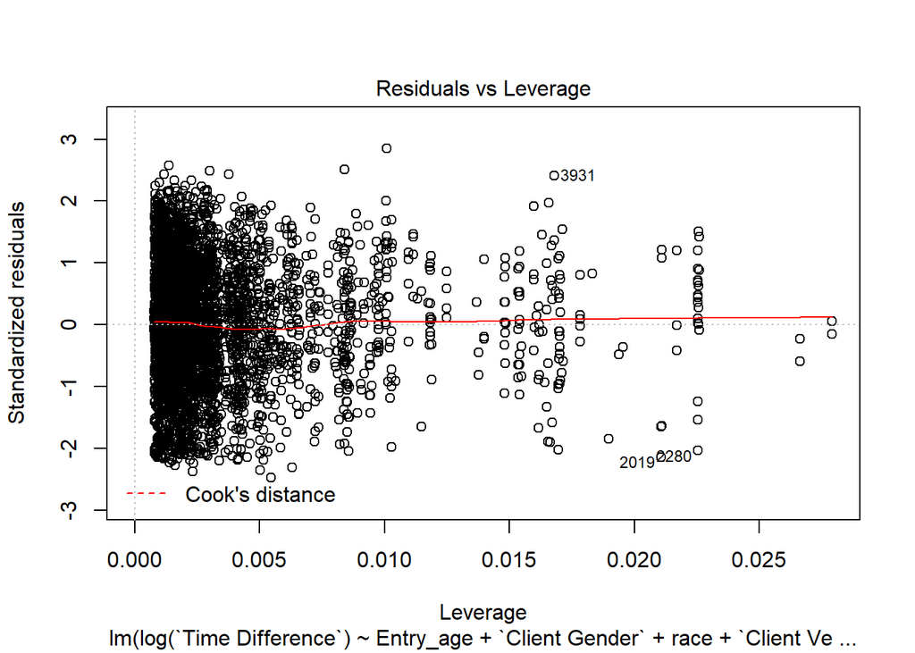

```r
plot(mod3)
```

We found that compared with non-veteran, those who are veteran usually stay less time at shelter; those who are older are more possible to stay longer; those who are homeless more than one year will be less possible to stay longer than those whose homeless time is less than 6 months. We found income also significant, but the absolute value of coefficient is not large.

## Problem 3: Check if there’s a trend regarding months

We want to explore if there’s some association regarding the months;

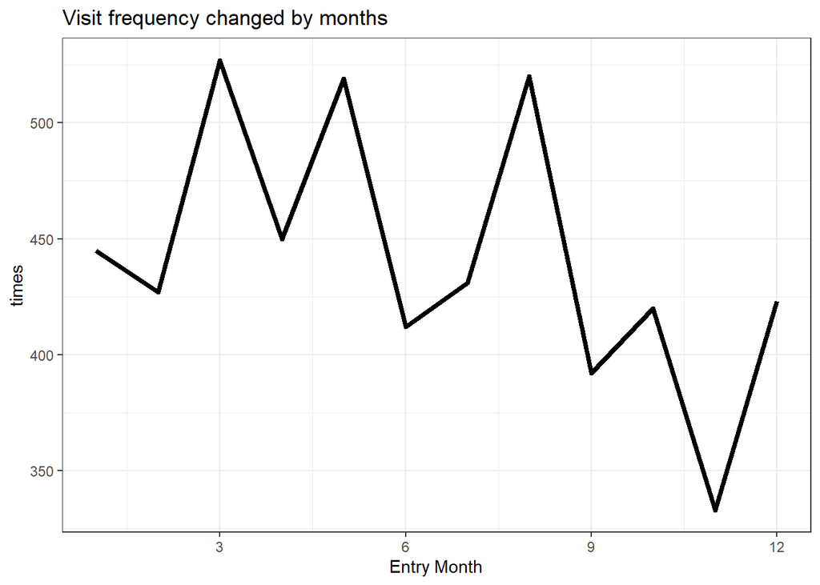

```r
client.entry%>%group_by(`Entry Month`)%>%summarise(times = n())%>%ggplot(aes(x=`Entry Month`,y = times))+geom_line(size=1.5)+labs(title = "Visit frequency changed by months")+theme_bw()+scale_x_continuous(breaks = seq(0,12,3))
```

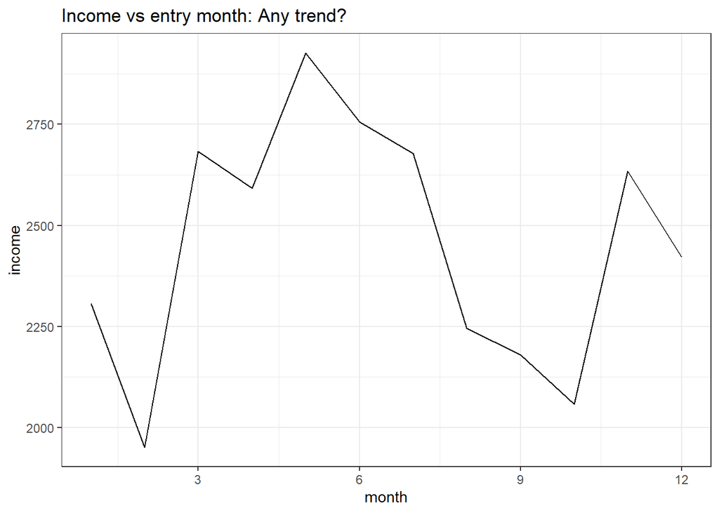

```r
client.entry%>%drop_na(income_month)%>%group_by(`Entry Month`)%>%summarise(money = mean(income_month))%>%
  ggplot(aes(x=`Entry Month`,y = money))+geom_line()+
  labs(x="month",y="income",title = "Income vs entry month: Any trend?")+scale_x_continuous(breaks = seq(0,12,3))+theme_bw()
```

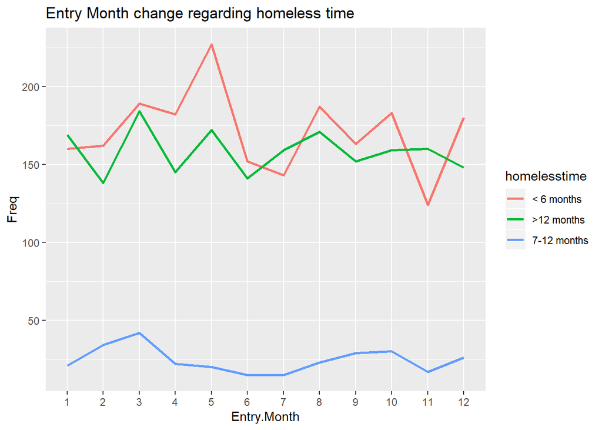

```r
dat1 = as.data.frame(table(client.entry%>%select(`Entry Month`,homelesstime)))
ggplot(dat1,aes(x=Entry.Month,y=Freq))+geom_line(aes(group=homelesstime,col = homelesstime),size=1)+labs(title = "Entry Month change regarding homeless time")
```

```r
chisq.test(table(client.entry%>%select(`Entry Month`,homelesstime)))
```

```
##
##  Pearson's Chi-squared test
##
## data:  table(client.entry %>% select(`Entry Month`, homelesstime))
## X-squared = 43.412, df = 22, p-value = 0.004197
```

## Conclusions

We’ve done lots of work, tried to explore the different dimensions of data and looked for the link with staying duration. The main composition of the shelter is black people, Non-hispanic, and male. Most of them are old people, and we found “Entry Age,gender,veteran status, ethnicity, disability count and homeless time” these variables are significant in linear model. And we indeed got some change before and after the entry of shelter. Also based on the result in python, 50% people didn’t complete the program when they select to leave. I think our next step analysis is to figure out what leads to their departure, is it correlated to any other feature? Besides, the prediction ability of the linear model is not good, we will explore more other potential influenced variables.